# Fake NHS Trust: Database inventory and column profile

Published

October 25, 2026

Every table below can be filtered: type in the box above a column, pick from its dropdown, or drag the slider under a number column; the search box matches any column. The CSV button downloads what is currently shown.

**45** tables and views, **518** columns, **54,368,976** rows in total. Profiled 518 columns in 45 tables in 24 seconds.

Last run started 2026-10-25 12:08:20 UTC against `duckdb_connection` (duckdb dialect), sampling tables above Inf rows, top 10 values per column, literal values suppressed for identifiers, free text and personal-data names.

**Phase 1: Inventory and profile**

### Tables

Ranked by row count. `newest_datetime` is the latest value in any date or datetime column, the freshness signal. Tables with no datetime column show blank.

| table_schema | table_name | table_type | n_columns | row_count | size | newest_datetime | newest_datetime_column |
| --- | --- | --- | --- | --- | --- | --- | --- |
| layer1 | pas_op_status_log | view | 8 | 21702836 |  | 2026-03-31 20:49:25 | recorded_datetime |
| derived | op_appointments | view | 28 | 6261732 |  | 2026-03-31 17:58:49 | t_arrived |
| layer1 | pas_outpatient_appointments | view | 16 | 6261732 |  | 2026-03-31 16:20:00 | appointment_datetime |
| layer1 | ed_status_log | view | 5 | 3396550 |  | 2026-04-02 17:23:14 | recorded_datetime |
| layer1 | pas_adt_events | view | 20 | 2723991 |  | 2026-04-28 19:36:29 | recorded_datetime |
| layer1 | pas_referrals | view | 11 | 2096135 |  | 2026-04-20 | rtt_period_end_date |
| derived | patient_identifiers | view | 3 | 1563120 |  |  |  |
| layer1 | ris_imaging | view | 29 | 968727 |  | 2026-06-22 16:40:56 | verified_datetime |
| derived | ward_stays | view | 10 | 966903 |  | 2026-04-04 06:01:42 | stay_start |
| aggregate | did_extract | view | 18 | 908031 |  | 2026-06-22 | date_test_report_issued |

[output cut: 35 more lines]

#### Freshness

How recent is each table? There is no reliable “last updated” stamp on a table, so the report takes the newest value in any of its date or datetime columns as its freshness: the latest moment the data describes. Tables with no date column have no freshness and show blank.

[figure not shown]

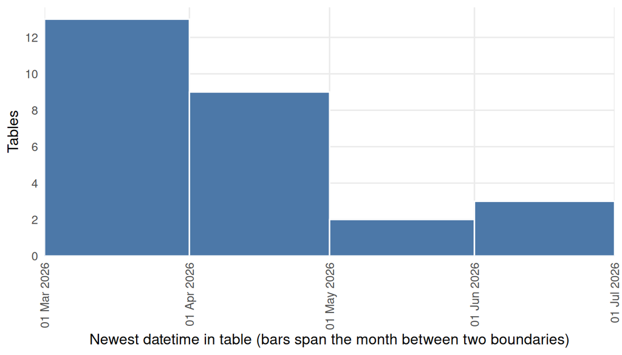

#### Row counts

Bins are log-spaced so that reference tables and multi-million-row logs both show; each bar covers the row counts between the two boundaries it sits on. Bars are not equal widths because 1 to 2 and 5 to 10 each double, while 2 to 5 is a factor of 2.5.

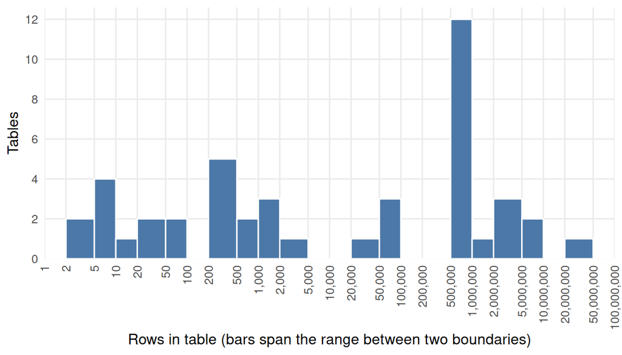

### Columns

#### Type mix

| type_class | columns |
| --- | --- |
| string | 311 |
| integer | 77 |
| datetime | 52 |
| date | 33 |
| boolean | 23 |
| numeric | 21 |
| complex | 1 |

#### Inferred semantic types

A first draft: `identifier`, `code`, `category`, `flag`, `date`, `datetime`, `free_text`, `count`, `measure`, `constant`, `empty`. For a person to confirm, not a finding.

| semantic_type | columns |
| --- | --- |
| code | 178 |
| count | 69 |
| identifier | 57 |
| category | 54 |
| datetime | 52 |
| date | 35 |
| flag | 35 |
| measure | 21 |
| free_text | 10 |
| constant | 4 |
| time | 2 |
| unknown | 1 |

#### Nulls and uniqueness

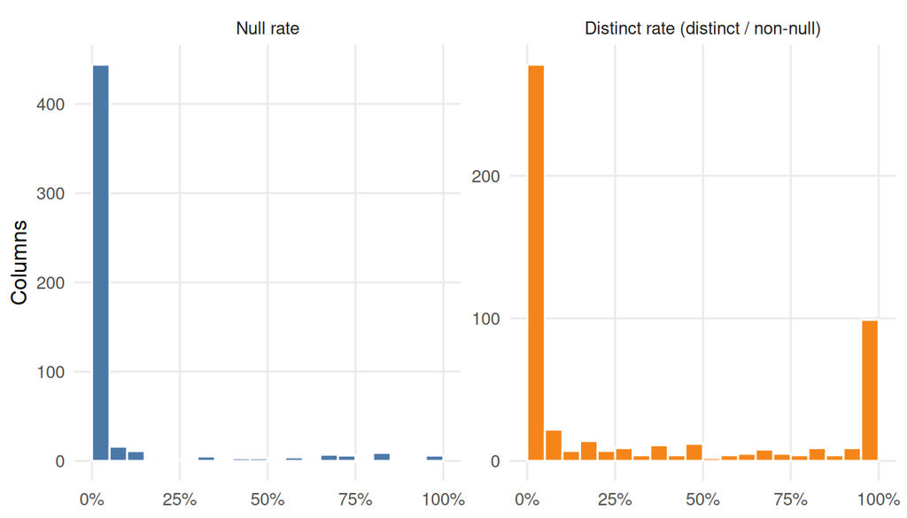

**0** columns are entirely null and **4** hold a single constant value: candidates to drop from any dictionary.

### Column profile

`pk_candidate` marks columns that are unique, never null and of a type keys are made of; where `sampled` is true that is evidence from the sample only. `top_values` lists the most frequent values with their counts; blank where values are suppressed or the column has too many distinct values for a frequency table to be useful.

| table_schema | table_name | column_name | data_type | semantic_type | row_count | null_rate | distinct_count | distinct_rate | is_unique | pk_candidate | min_value | max_value | mean_value | top_values | sampled |
| --- | --- | --- | --- | --- | --- | --- | --- | --- | --- | --- | --- | --- | --- | --- | --- |
| aggregate | ae_monthly | month | DATE | date | 72 | 0 | 36 | 0.5 | FALSE | FALSE | 2023-04-01 | 2026-03-01 |  | 2023-04-01 (2);2023-05-01 (2);2023-06-01 (2);2023-07-01 (2);2023-08-01 (2);2023-09-01 (2);2023-10-01 (2);2023-11-01 (2);2023-12-01 (2);2024-01-01 (2);2024-02-01 (2);2024-03-01 (2);2024-04-01 (2);2024-… | FALSE |
| aggregate | ae_monthly | site_code | VARCHAR | constant | 72 | 0 | 1 | 0.014 | FALSE | FALSE | RZ901 | RZ901 |  | RZ901 (72) | FALSE |
| aggregate | ae_monthly | department_type | VARCHAR | code | 72 | 0 | 2 | 0.028 | FALSE | FALSE | Type 1 | Type 3 |  | Type 1 (36);Type 3 (36) | FALSE |
| aggregate | ae_monthly | attendances | BIGINT | identifier | 72 | 0 | 71 | 0.986 | FALSE | FALSE | 7571 | 14597 | 11054.861 | 13988 (2);12322 (1);12500 (1);12658 (1);13000 (1);13067 (1);13330 (1);13452 (1);13465 (1);13490 (1) | FALSE |
| aggregate | ae_monthly | within_4h | BIGINT | identifier | 72 | 0 | 72 | 1 | TRUE | TRUE | 6805 | 10492 | 8483.167 | 10095 (1);10254 (1);10309 (1);10469 (1);10492 (1);6805 (1);6894 (1);6978 (1);7021 (1);7174 (1) | FALSE |
| aggregate | ae_monthly | over_4h | BIGINT | identifier | 72 | 0 | 71 | 0.986 | FALSE | FALSE | 550 | 5552 | 2571.694 | 613 (2);1040 (1);1043 (1);1045 (1);1057 (1);1101 (1);1186 (1);3437 (1);3562 (1);3685 (1) | FALSE |
| aggregate | ae_monthly | pct_within_4h | DOUBLE | measure | 72 | 0 | 56 | 0.778 | FALSE | FALSE | 60.3 | 93.2 | 79.517 | 72.3 (3);92.4 (3);71.9 (2);72.0 (2);72.4 (2);87.8 (2);89.4 (2);89.5 (2);91.3 (2);92.0 (2) | FALSE |
| aggregate | ae_monthly | emergency_admissions_via_ed | BIGINT | count | 72 | 0 | 63 | 0.875 | FALSE | FALSE | 140 | 4228 | 2038 | 170 (3);183 (3);165 (2);169 (2);173 (2);175 (2);184 (2);140 (1);142 (1);145 (1) | FALSE |
| aggregate | ae_monthly | dta_to_admission_over_4h | BIGINT | count | 72 | 0 | 52 | 0.722 | FALSE | FALSE | 15 | 914 | 339.681 | 21 (6);27 (5);26 (4);28 (4);18 (2);23 (2);30 (2);40 (2);523 (2);15 (1) | FALSE |
| aggregate | ae_monthly | dta_to_admission_over_12h | BIGINT | count | 72 | 0 | 48 | 0.667 | FALSE | FALSE | 2 | 367 | 103.069 | 11 (6);4 (5);17 (3);6 (3);7 (3);8 (3);10 (2);122 (2);130 (2);16 (2);2 (2);252 (2);9 (2);105 (1);115 (1);12 (1);123 (1);127 (1);129 (1);13 (1);135 (1);14 (1);141 (1);142 (1);145 (1);148 (1);149 (1);15 … | FALSE |

[output cut: 508 more lines]

**Phase 2: Table clusters**

Which tables hold the same data? This tab groups them and proposes, for each group, the one table to keep and document (the **canonical** member). It works in five steps, from the column profile alone.

[figure not shown]

#### What counts as the same data

Two tables are related when most of one table’s information is found in the other **and** they share a column that is near-unique in both: the same identifier for the same things. Sharing a code column is not enough, otherwise every table that references the site list would look like a copy of it.

[figure not shown]

#### The labels

Each related table is labelled by its shape relative to the canonical member of its group.

The canonical member is proposed as the table with the lowest grain (most rows), the most columns, the newest data and a key, and a *narrower* table is the other side of a wider derivative. **These are proposals**: the warehouse owners confirm or reject each one in the review file (`decisions` in `inventory_run()`), and confirmed decisions override the proposals on later runs. Full detail of the scoring: `?cluster_tables`.

#### Proposed groups

**4** groups of related tables among **45** tables; **35** tables stand alone. Table classes from their own shape: 8 aggregate, 22 event, 15 reference.

| cluster_id | table | table_class | role | canonical | row_count | n_columns | newest_datetime | confidence | status | rationale |
| --- | --- | --- | --- | --- | --- | --- | --- | --- | --- | --- |
| 4 | derived.imaging_exams | event | canonical | derived.imaging_exams | 907909 | 32 | 2026-06-22 17:40:56 | 0.15 | proposed | Chosen: 907,909 rows, 32 columns, newest 2026-06-22. aggregate.did_extract: narrower (908,031 rows, 18 columns); layer1.ris_imaging: copy (968,727 rows, 29 columns) |
| 4 | aggregate.did_extract | event | narrower | derived.imaging_exams | 908031 | 18 | 2026-06-22 | 0.15 | proposed | Chosen: 907,909 rows, 32 columns, newest 2026-06-22. aggregate.did_extract: narrower (908,031 rows, 18 columns); layer1.ris_imaging: copy (968,727 rows, 29 columns) |
| 4 | layer1.ris_imaging | event | copy | derived.imaging_exams | 968727 | 29 | 2026-06-22 16:40:56 | 0.15 | proposed | Chosen: 907,909 rows, 32 columns, newest 2026-06-22. aggregate.did_extract: narrower (908,031 rows, 18 columns); layer1.ris_imaging: copy (968,727 rows, 29 columns) |
| 11 | layer1.ed_attendances | event | canonical | layer1.ed_attendances | 795950 | 22 | 2026-04-02 17:21:35 | 0.31 | proposed | Chosen: 795,950 rows, 22 columns, has a key candidate, newest 2026-04-02. derived.ed_attendances: wider derivative (795,950 rows, 27 columns) |
| 11 | derived.ed_attendances | event | wider_derivative | layer1.ed_attendances | 795950 | 27 | 2026-04-02 17:21:14 | 0.31 | proposed | Chosen: 795,950 rows, 22 columns, has a key candidate, newest 2026-04-02. derived.ed_attendances: wider derivative (795,950 rows, 27 columns) |
| 14 | derived.patients | event | canonical | derived.patients | 800530 | 12 | 2026-05-18 | 0.01 | proposed | Chosen: 800,530 rows, 12 columns, has a key candidate, newest 2026-05-18. derived.mrn_map: narrower (805,246 rows, 5 columns); layer1.pas_patients: copy (805,246 rows, 10 columns) |
| 14 | derived.mrn_map | event | narrower | derived.patients | 805246 | 5 |  | 0.01 | proposed | Chosen: 800,530 rows, 12 columns, has a key candidate, newest 2026-05-18. derived.mrn_map: narrower (805,246 rows, 5 columns); layer1.pas_patients: copy (805,246 rows, 10 columns) |
| 14 | layer1.pas_patients | event | copy | derived.patients | 805246 | 10 | 2026-05-18 | 0.01 | proposed | Chosen: 800,530 rows, 12 columns, has a key candidate, newest 2026-05-18. derived.mrn_map: narrower (805,246 rows, 5 columns); layer1.pas_patients: copy (805,246 rows, 10 columns) |
| 15 | derived.op_appointments | event | canonical | derived.op_appointments | 6261732 | 28 | 2026-03-31 17:58:49 | 0.39 | proposed | Chosen: 6,261,732 rows, 28 columns, has a key candidate, newest 2026-03-31. layer1.pas_outpatient_appointments: copy (6,261,732 rows, 16 columns) |
| 15 | layer1.pas_outpatient_appointments | event | copy | derived.op_appointments | 6261732 | 16 | 2026-03-31 16:20:00 | 0.39 | proposed | Chosen: 6,261,732 rows, 28 columns, has a key candidate, newest 2026-03-31. layer1.pas_outpatient_appointments: copy (6,261,732 rows, 16 columns) |

#### Every table and its class

`event` tables carry identifiers and are where activity is recorded; `reference` tables are small code lists with a key; `aggregate` tables summarise by date or code with no identifiers.

| table | table_class | cluster_id | role | canonical | row_count | n_columns | status |
| --- | --- | --- | --- | --- | --- | --- | --- |
| aggregate.ae_monthly | event | 1 | standalone | aggregate.ae_monthly | 72 | 11 | proposed |
| aggregate.apc_monthly | aggregate | 2 | standalone | aggregate.apc_monthly | 2739 | 13 | proposed |
| aggregate.daily_flow | aggregate | 3 | standalone | aggregate.daily_flow | 30547 | 9 | proposed |
| aggregate.did_extract | event | 4 | narrower | derived.imaging_exams | 908031 | 18 | proposed |
| aggregate.did_monthly | aggregate | 5 | standalone | aggregate.did_monthly | 700 | 8 | proposed |
| aggregate.dm01_snapshot | aggregate | 6 | standalone | aggregate.dm01_snapshot | 252 | 17 | proposed |
| aggregate.endoscopy_monthly | aggregate | 7 | standalone | aggregate.endoscopy_monthly | 1193 | 11 | proposed |
| aggregate.midnight_census | aggregate | 8 | standalone | aggregate.midnight_census | 57169 | 5 | proposed |
| aggregate.op_monthly | aggregate | 9 | standalone | aggregate.op_monthly | 1044 | 11 | proposed |
| aggregate.rtt_incomplete | aggregate | 10 | standalone | aggregate.rtt_incomplete | 648 | 9 | proposed |

[output cut: 35 more lines]

#### Evidence for each related pair

`contain_a_in_b` is the share of A’s information found in B (weighted by how informative each column is), and the reverse; `shared_entity_exact` means an identifier with identical values in both.

| table_a | relationship_a | table_b | relationship_b | contain_a_in_b | contain_b_in_a | n_matches | shared_entity_exact |
| --- | --- | --- | --- | --- | --- | --- | --- |
| derived.patients | copy | layer1.pas_patients | copy | 0.81 | 0.95 | 9 | 1 |
| reference.admission_source | related | reference.discharge_destination | related | 0.87 | 0.87 | 2 | 0 |
| derived.op_appointments | copy | layer1.pas_outpatient_appointments | copy | 0.62 | 0.97 | 16 | 1 |
| derived.imaging_exams | copy | layer1.ris_imaging | copy | 0.73 | 0.74 | 23 | 1 |
| derived.rtt_pathways | related | layer1.pas_referrals | related | 0.6 | 0.86 | 10 | 0 |
| derived.mrn_map | narrower | derived.patients | wider_derivative | 0.67 | 0.29 | 2 | 1 |
| derived.ed_attendances | wider_derivative | layer1.ed_attendances | narrower | 0.31 | 0.39 | 12 | 1 |
| aggregate.did_extract | narrower | layer1.ris_imaging | wider_derivative | 0.47 | 0.25 | 9 | 1 |
| derived.mrn_map | narrower | layer1.pas_patients | wider_derivative | 0.33 | 0.17 | 1 | 1 |
| aggregate.did_extract | narrower | derived.imaging_exams | wider_derivative | 0.2 | 0.1 | 5 | 1 |

### Candidate duplicate columns

Groups of columns in different tables whose contents look the same: same type class, same order of magnitude of distinct values, same minimum and maximum and the same most frequent values, hashed together as a fingerprint. Each row is one group, listing every column in it; a group spanning a source table and a derived table is probably a copy, and columns matching under different names are the ones worth checking first. It is a starting point for the duplicate map, not a verdict: value-overlap tests confirm or reject it in the next stage.

| fingerprint | n_columns | n_tables | columns |
| --- | --- | --- | --- |
| 84a8f4dbd875e6be | 8 | 7 | derived.episodes.person_idderived.imaging_exams.mrn_as_recordedderived.imaging_exams.person_idderived.rtt_pathways.person_idderived.spells.person_idderived.ward_stays.person_idlayer1.pas_adt_events.mr… |
| 32757a55884a8994 | 5 | 5 | aggregate.ae_monthly.monthaggregate.apc_monthly.monthaggregate.did_monthly.monthaggregate.endoscopy_monthly.monthaggregate.op_monthly.month |
| e7f08b2e2f83cd7a | 7 | 4 | derived.mrn_map.after_mergederived.mrn_map.mrnderived.mrn_map.person_mrnderived.patient_identifiers.person_idderived.patients.mrnderived.patients.person_idlayer1.pas_patients.mrn |
| 07b6421dd99a12da | 4 | 4 | derived.episodes.provspnoderived.spells.provspnoderived.ward_stays.provspnolayer1.pas_adt_events.visit_number |
| 251ca5408c9eb656 | 4 | 3 | aggregate.did_extract.ris_accession_numberderived.imaging_exams.accession_numberderived.imaging_exams.accession_stemlayer1.ris_imaging.accession_number |
| 64bc0754bb4edaf4 | 4 | 3 | derived.op_appointments.mrn_as_recordedderived.op_appointments.person_idlayer1.pas_outpatient_appointments.mrnlayer1.pas_referrals.mrn |
| 10ede83d6196d66a | 3 | 3 | aggregate.did_extract.imaging_code_nicipderived.imaging_exams.nicip_codelayer1.ris_imaging.nicip_code |
| 1f3dbee8008b6325 | 3 | 3 | derived.episodes.consultant_codederived.spells.consultant_lastlayer1.pas_adt_events.consultant_code |
| 31c1270b5fd7e8ce | 3 | 3 | aggregate.did_extract.date_of_birthderived.patients.doblayer1.pas_patients.dob |
| 32cfcf47f463be4c | 3 | 3 | derived.ed_attendances.aekeylayer1.ed_attendances.uec_activity_identifierlayer1.ed_status_log.uec_activity_identifier |

[output cut: 30 more lines]

**Phase 3: Keys**

Keys are how tables join. A **primary key candidate** is a column that identifies each row: every value is different and none is missing. A **foreign key candidate** is a column whose values point at some other table’s key: a patient identifier repeated across admissions, say. Both are proposed from the profile; confirming them is the key register’s job in the next stage.

[figure not shown]

### Primary key candidates

Columns that are unique, never null and of a type keys are made of. On a full run these are exact facts about the data, not estimates; whether a column *is* the key is still a decision for the key register.

| table_schema | table_name | column_name | data_type | semantic_type | row_count | distinct_count |
| --- | --- | --- | --- | --- | --- | --- |
| aggregate | ae_monthly | within_4h | BIGINT | identifier | 72 | 72 |
| derived | ed_attendances | aekey | VARCHAR | identifier | 795950 | 795950 |
| derived | endoscopy_procedures | proc_id | VARCHAR | identifier | 70250 | 70250 |
| derived | episodes | epikey | VARCHAR | identifier | 889232 | 889232 |
| derived | mrn_map | mrn | VARCHAR | identifier | 805246 | 805246 |
| derived | op_appointments | attendkey | VARCHAR | identifier | 6261732 | 6261732 |
| derived | patients | person_id | VARCHAR | identifier | 800530 | 800530 |
| derived | patients | mrn | VARCHAR | identifier | 800530 | 800530 |
| derived | ref_ward_names | raw | VARCHAR | identifier | 232 | 232 |
| derived | rtt_pathways | rtt_pathway_id | VARCHAR | identifier | 715447 | 715447 |

[output cut: 35 more lines]

### Foreign key candidates

Columns that look like references to a key column in another table, scored from profile statistics alone. **These are candidates, not confirmed relationships**: confirming one needs a match-rate query (what share of the child’s values exist in the key), which is the key register’s job in the next stage.

A pair is excluded outright when the types differ, the child’s string lengths fall outside the key’s, a unique child shares the key’s fingerprint (a copy, not a reference), the key’s full value set is known and the child uses a value outside it, the child has more distinct values than a fully profiled key, the shapes of their values do not overlap (`100` cannot reference `Ward 3`), the child is a flag, the key is in the child’s own table without a self-referencing name, or the child is itself a key with no name evidence. Surviving pairs start at 0.1 and add: name evidence (0.45 same name, 0.3 child name ends with the key name, 0.2 child name contains the key’s table stem; generic names like `id` or `code` earn nothing); up to 0.4 when every child value is in the key’s known value set, scaled by how much of the set the child uses; 0.25 (or -0.25) for the child’s range lying inside (or outside) the key’s when the value set is unknown; 0.15 for a many-to-one shape or 0.05 for one-to-one; 0.1 for identical string lengths. The best target at or above 0.6 is reported; `n_targets` counts the keys that qualified, since a conformed code such as a site code legitimately matches several. Full detail: `?infer_foreign_keys`.

| child | target | confidence | n_targets | child_sampled | evidence |
| --- | --- | --- | --- | --- | --- |
| aggregate.ae_monthly.site_code | reference.sites.site_code | 1 | 1 | FALSE | name=exactvalues=within(1 of 2)range=unknowncardinality=many_to_onelength=match |
| aggregate.apc_monthly.site_code | reference.sites.site_code | 1 | 1 | FALSE | name=exactvalues=within(2 of 2)range=unknowncardinality=many_to_onelength=match |
| aggregate.daily_flow.site_code | reference.sites.site_code | 1 | 1 | FALSE | name=exactvalues=within(2 of 2)range=unknowncardinality=many_to_onelength=match |
| aggregate.did_extract.provider_site_code | reference.sites.site_code | 1 | 1 | FALSE | name=suffixvalues=within(2 of 2)range=unknowncardinality=many_to_onelength=match |
| aggregate.endoscopy_monthly.site_code | reference.sites.site_code | 1 | 1 | FALSE | name=exactvalues=within(2 of 2)range=unknowncardinality=many_to_onelength=match |
| aggregate.midnight_census.site_code | reference.sites.site_code | 1 | 1 | FALSE | name=exactvalues=within(2 of 2)range=unknowncardinality=many_to_onelength=match |
| aggregate.midnight_census.ward_id | reference.wards.ward_id | 1 | 1 | FALSE | name=exactvalues=unknownrange=withincardinality=many_to_onelength=match |
| aggregate.op_monthly.site_code | reference.sites.site_code | 1 | 1 | FALSE | name=exactvalues=within(2 of 2)range=unknowncardinality=many_to_onelength=match |
| derived.endoscopy_procedures.site_code | reference.sites.site_code | 1 | 1 | FALSE | name=exactvalues=within(2 of 2)range=unknowncardinality=many_to_onelength=match |
| derived.imaging_exams.site_code | reference.sites.site_code | 1 | 1 | FALSE | name=exactvalues=within(2 of 2)range=unknowncardinality=many_to_onelength=match |

[output cut: 80 more lines]